# Study 2

## (1) Description of Data

The posted data for this study consists of 1 compiled, deidentified data file. The lexical decision task data was cleaned and scored in Excel according to procedures from Lisjak et al., 2012, Study 2:

- Total trials before cleaning: 7040
- Total error trials removed: 341 (4.84%)
- Total extreme responses (>3500ms) removed: 4 (0.06%)
- Total outliers removed (after removing errors and extreme responses): 126 (1.79%)

## (2) Descriptive Statistics

**Total *N*:** 88

**Sensitivity analysis:** This sample provided a statistical power of .80 to detect effects of *f*<sup>2</sup> >= 0.091.

**Percentage by gender:**

```
## gender
## female   male   <NA>
##     48     37      3
```

*N* in each condition:

```
## cond
##  friend student    <NA>
##      42      46       0
```

*M*s and *SD*s:

```
##          n  mean   sd
## Age     85 19.12 1.00
## rfs     86  0.08 0.76
## rfs.pro 86  5.58 0.90
## rfs.pre 86  5.50 0.95
## rfb     87  0.37 0.79
## rfb.pro 87  5.04 1.09
## rfb.pre 87  4.67 1.04
## rfq     86  0.45 0.99
## rfq.pro 86  3.81 0.63
## rfq.pre 86  3.36 0.95
```

**Alphas:**

- **Identity-specific motivation-academics promotion:** 0.72
- **Identity-specific motivation-academics prevention:** 0.75
- **Identity-specific motivation-friend promotion:** 0.83
- **Identity-specific motivation-friend prevention:** 0.67
- **RFQ promotion:** 0.69
- **RFQ prevention:** 0.84

## (3) Correlations

**Correlations:**

```
##         lower    r upper      p df
## rfs-rfb  0.14 0.34  0.52 0.0015 83
## rfs-rfq -0.06 0.16  0.36 0.1518 84
## rfb-rfq -0.09 0.13  0.33 0.2525 83
```

## (4) Random assignment checks

**(a) Unequal variance test, *t*-test, and *M*s and *SD*s for: identity-specific motivation-student**

```
##
##  F test to compare two variances
##
## data:  rfs by cond
## F = 0.51593, num df = 41, denom df = 43, p-value = 0.03534
## alternative hypothesis: true ratio of variances is not equal to 1
## 95 percent confidence interval:
##  0.2800313 0.9548490
## sample estimates:
## ratio of variances
##          0.5159277
```

```
##
##  Welch Two Sample t-test
##
## data:  rfs by cond
## t = 0.99445, df = 78.112, p-value = 0.3231
## alternative hypothesis: true difference in means is not equal to 0
## 95 percent confidence interval:
##  -0.1612940  0.4832637
## sample estimates:
##  mean in group friend mean in group student
##           0.166666667           0.005681818
```

```
##
##  Descriptive statistics by group
## group: friend
##    vars  n mean   sd median trimmed  mad   min  max range skew kurtosis  se
## X1    1 42 0.17 0.62      0    0.13 0.37 -1.25 1.75     3 0.47     0.15 0.1
## ---------------------------------------------------------------------------
## group: student
##    vars  n mean   sd median trimmed  mad  min max range  skew kurtosis   se
## X1    1 44 0.01 0.87      0    0.01 0.74 -2.5   2   4.5 -0.26     0.45 0.13
```

**(b) Unequal variance test, *t*-test, and *M*s and *SD*s for: identity-specific motivation-friend**

```
##
##  F test to compare two variances
##
## data:  rfb by cond
## F = 0.60917, num df = 41, denom df = 44, p-value = 0.1121
## alternative hypothesis: true ratio of variances is not equal to 1
## 95 percent confidence interval:
##  0.3321475 1.1246552
## sample estimates:
## ratio of variances
##           0.609167
```

```
##
##  Two Sample t-test
##
## data:  rfb by cond
## t = 0.48693, df = 85, p-value = 0.6276
## alternative hypothesis: true difference in means is not equal to 0
## 95 percent confidence interval:
##  -0.2569384  0.4236051
## sample estimates:
##  mean in group friend mean in group student
##             0.4166667             0.3333333
```

```
##
##  Descriptive statistics by group
## group: friend
##    vars  n mean   sd median trimmed  mad   min max range skew kurtosis   se
## X1    1 42 0.42 0.69   0.25    0.39 0.74 -0.75   2  2.75 0.27       -1 0.11
## ---------------------------------------------------------------------------
## group: student
##    vars  n mean   sd median trimmed  mad   min  max range  skew kurtosis   se
## X1    1 45 0.33 0.89   0.25    0.36 1.11 -2.25 2.25   4.5 -0.37     0.26 0.13
```

**(c) Unequal variance test, *t*-test, and *M*s and *SD*s for: RFQ**

```
##
##  F test to compare two variances
##
## data:  rfq by cond
## F = 1.2039, num df = 41, denom df = 43, p-value = 0.5484
## alternative hypothesis: true ratio of variances is not equal to 1
## 95 percent confidence interval:
##  0.6534574 2.2281548
## sample estimates:
## ratio of variances
##           1.203925
```

```
##
##  Two Sample t-test
##
## data:  rfq by cond
## t = 1.3344, df = 84, p-value = 0.1857
## alternative hypothesis: true difference in means is not equal to 0
## 95 percent confidence interval:
##  -0.1385166  0.7035238
## sample estimates:
##  mean in group friend mean in group student
##             0.5984127             0.3159091
```

```
##
##  Descriptive statistics by group
## group: friend
##    vars  n mean   sd median trimmed  mad   min  max range skew kurtosis   se
## X1    1 42  0.6 1.03   0.58    0.54 1.06 -0.97 3.43   4.4 0.45    -0.19 0.16
## ---------------------------------------------------------------------------
## group: student
##    vars  n mean   sd median trimmed  mad   min  max range skew kurtosis   se
## X1    1 44 0.32 0.94   0.23    0.27 0.96 -1.27 2.53   3.8 0.48    -0.23 0.14
```

## (5) Main Analyses

#### Promotion analyses

**Estimates and CIs:**

```
##
## Call:
## lm(formula = promolog ~ rfprimed_c + rfnonprimed_c + rfq_c +
##     prevlog_c)
##
## Residuals:
##       Min        1Q    Median        3Q       Max
## -0.269265 -0.034741 -0.006065  0.039058  0.174744
##
## Coefficients:
##                Estimate Std. Error t value Pr(>|t|)
## (Intercept)    6.430385   0.007756 829.035  < 2e-16 ***
## rfprimed_c    -0.042868   0.010695  -4.008 0.000137 ***
## rfnonprimed_c  0.003526   0.010716   0.329 0.742977
## rfq_c         -0.006283   0.008333  -0.754 0.453031
## prevlog_c      0.824671   0.057454  14.354  < 2e-16 ***
## ---
## Signif. codes:  0 '***' 0.001 '**' 0.01 '*' 0.05 '.' 0.1 ' ' 1
##
## Residual standard error: 0.07144 on 80 degrees of freedom
##   (3 observations deleted due to missingness)
## Multiple R-squared:  0.7297, Adjusted R-squared:  0.7162
## F-statistic: 53.99 on 4 and 80 DF,  p-value: < 2.2e-16
```

```
##               2.5 % 97.5 %
## (Intercept)    6.41   6.45
## rfprimed_c    -0.06  -0.02
## rfnonprimed_c -0.02   0.02
## rfq_c         -0.02   0.01
## prevlog_c      0.71   0.94
```

*f*<sup>2</sup> value (effect size) for identity-specific motivation-primed: 0.201

*f*<sup>2</sup> value (effect size) for RFQ: 0.007

#### Prevention analyses

**Estimates and CIs:**

```
##
## Call:
## lm(formula = prevlog ~ rfprimed_c + rfnonprimed_c + rfq_c + promolog_c)
##
## Residuals:
##       Min        1Q    Median        3Q       Max
## -0.149046 -0.038281 -0.003411  0.025282  0.287619
##
## Coefficients:
##                 Estimate Std. Error t value Pr(>|t|)
## (Intercept)    6.4608773  0.0079847 809.155  < 2e-16 ***
## rfprimed_c     0.0491214  0.0107390   4.574 1.72e-05 ***
## rfnonprimed_c -0.0003658  0.0110355  -0.033   0.9736
## rfq_c          0.0151268  0.0084381   1.793   0.0768 .
## promolog_c     0.8734471  0.0608520  14.354  < 2e-16 ***
## ---
## Signif. codes:  0 '***' 0.001 '**' 0.01 '*' 0.05 '.' 0.1 ' ' 1
##
## Residual standard error: 0.07352 on 80 degrees of freedom
##   (3 observations deleted due to missingness)
## Multiple R-squared:  0.7554, Adjusted R-squared:  0.7432
## F-statistic: 61.78 on 4 and 80 DF,  p-value: < 2.2e-16
```

```
##               2.5 % 97.5 %
## (Intercept)    6.44   6.48
## rfprimed_c     0.03   0.07
## rfnonprimed_c -0.02   0.02
## rfq_c          0.00   0.03
## promolog_c     0.75   0.99
```

*f*<sup>2</sup> value (effect size) for identity-specific motivation-primed: 0.262

*f*<sup>2</sup> value (effect size) for RFQ: 0.04

## (6) Plots

These plots use non-logged RTs and non-centered values for visualization purposes.

### Promotion plot

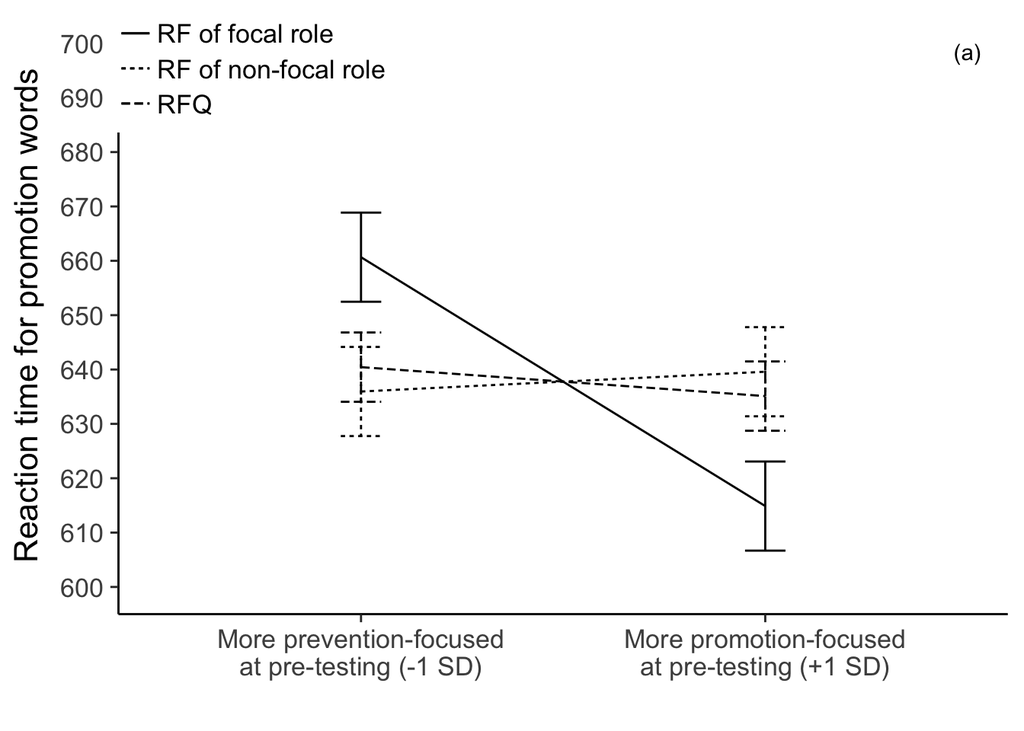

### Prevention plot

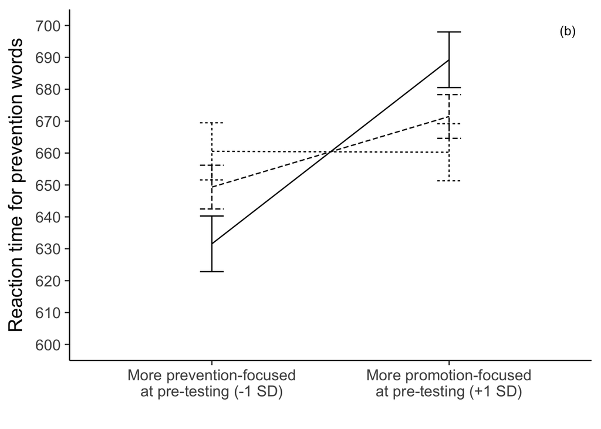

## (7) Supplementary Analyses

### Promotion Analyses

#### Regressing on RT for promotion words on main effects

```
##
## Call:
## lm(formula = promolog ~ cond_c + rfs_c + rfb_c + rfq_c + prevlog_c)
##
## Residuals:
##      Min       1Q   Median       3Q      Max
## -0.28218 -0.04491 -0.01294  0.05029  0.17269
##
## Coefficients:
##              Estimate Std. Error t value Pr(>|t|)
## (Intercept)  6.429721   0.008051 798.635  < 2e-16 ***
## cond_c      -0.006126   0.016265  -0.377  0.70746
## rfs_c       -0.005460   0.011903  -0.459  0.64768
## rfb_c       -0.031937   0.010934  -2.921  0.00455 **
## rfq_c       -0.003297   0.008660  -0.381  0.70439
## prevlog_c    0.806107   0.059308  13.592  < 2e-16 ***
## ---
## Signif. codes:  0 '***' 0.001 '**' 0.01 '*' 0.05 '.' 0.1 ' ' 1
##
## Residual standard error: 0.07413 on 79 degrees of freedom
##   (3 observations deleted due to missingness)
## Multiple R-squared:  0.7126, Adjusted R-squared:  0.6944
## F-statistic: 39.17 on 5 and 79 DF,  p-value: < 2.2e-16
```

```
##             2.5 % 97.5 %
## (Intercept)  6.41   6.45
## cond_c      -0.04   0.03
## rfs_c       -0.03   0.02
## rfb_c       -0.05  -0.01
## rfq_c       -0.02   0.01
## prevlog_c    0.69   0.92
```

#### Regression with interactions added

```
##
## Call:
## lm(formula = promolog ~ cond_c + rfs_c + rfb_c + rfq_c + cond_c:rfs_c +
##     cond_c:rfb_c + cond_c:rfq_c + prevlog_c)
##
## Residuals:
##       Min        1Q    Median        3Q       Max
## -0.271698 -0.038836 -0.002373  0.041710  0.158768
##
## Coefficients:
##               Estimate Std. Error t value Pr(>|t|)
## (Intercept)   6.428995   0.007841 819.894  < 2e-16 ***
## cond_c       -0.005522   0.015693  -0.352  0.72589
## rfs_c        -0.007632   0.011891  -0.642  0.52291
## rfb_c        -0.033584   0.010792  -3.112  0.00262 **
## rfq_c        -0.008165   0.008581  -0.951  0.34440
## prevlog_c     0.836286   0.058478  14.301  < 2e-16 ***
## cond_c:rfs_c  0.042032   0.023647   1.778  0.07949 .
## cond_c:rfb_c -0.060726   0.021825  -2.782  0.00680 **
## cond_c:rfq_c  0.012303   0.016650   0.739  0.46224
## ---
## Signif. codes:  0 '***' 0.001 '**' 0.01 '*' 0.05 '.' 0.1 ' ' 1
##
## Residual standard error: 0.07139 on 76 degrees of freedom
##   (3 observations deleted due to missingness)
## Multiple R-squared:  0.7435, Adjusted R-squared:  0.7165
## F-statistic: 27.54 on 8 and 76 DF,  p-value: < 2.2e-16
```

```
##              2.5 % 97.5 %
## (Intercept)   6.41   6.44
## cond_c       -0.04   0.03
## rfs_c        -0.03   0.02
## rfb_c        -0.06  -0.01
## rfq_c        -0.03   0.01
## prevlog_c     0.72   0.95
## cond_c:rfs_c -0.01   0.09
## cond_c:rfb_c -0.10  -0.02
## cond_c:rfq_c -0.02   0.05
```

*f*<sup>2</sup> value (effect size) for condition x identity-specific motivation-student interaction term: 0.042  
*f*<sup>2</sup> value (effect size) for condition x identity-specific motivation-friend interaction term: 0.102

*f*<sup>2</sup> value (effect size) for condition x RFQ interaction term: 0.007

#### Simple effects of identity-specific motivation-student in each condition

**Estimates and CIs:**

```
##         [,1]
## friend     1
## student   -1
```

```
##
## ** Estimated points of promolog  **
##
##                     Low rfs_c (-1 SD) High rfs_c (+1 SD)
## Low cond_c (-1 SD)             6.4517             6.4105
## High cond_c (+1 SD)            6.4160             6.4369
##
##
##
## ** Simple Slopes analysis ( df= 76 ) **
##
##                     simple slope standard error t-value p.value
## Low cond_c (-1 SD)       -0.0281         0.0151   -1.86   0.067 .
## High cond_c (+1 SD)       0.0142         0.0185    0.77   0.444
## ---
## Signif. codes:  0 '***' 0.001 '**' 0.01 '*' 0.05 '.' 0.1 ' ' 1
##
##
##
## ** Bauer & Curran 95% CI **
##
##        lower CI upper CI
## cond_c  -2.0032  -0.6347
```

**CIs in the student condition:** -0.06, 0

**CIs in the friend condition:** -0.02, 0.05

#### Simple effects of identity-specific motivation-friend in each condition

**Estimates and CIs:**

```
##         [,1]
## friend     1
## student   -1
```

```
##
## ** Estimated points of promolog  **
##
##                     Low rfb_c (-1 SD) High rfb_c (+1 SD)
## Low cond_c (-1 SD)             6.4349             6.4284
## High cond_c (+1 SD)            6.4777             6.3738
##
##
##
## ** Simple Slopes analysis ( df= 76 ) **
##
##                     simple slope standard error t-value p.value
## Low cond_c (-1 SD)       -0.0041         0.0141   -0.29  0.7742
## High cond_c (+1 SD)      -0.0651         0.0166   -3.92  0.0002 ***
## ---
## Signif. codes:  0 '***' 0.001 '**' 0.01 '*' 0.05 '.' 0.1 ' ' 1
##
##
##
## ** Bauer & Curran 95% CI **
##
##        lower CI upper CI
## cond_c  -1.8749  -0.1954
```

**CIs in the student condition:** -0.03, 0.02

**CIs in the friend condition:** -0.1, -0.03

#### Simple effects of RFQ in each condition

**Estimates and CIs:**

```
##         [,1]
## friend     1
## student   -1
```

```
##
## ** Estimated points of promolog  **
##
##                     Low rfq_c (-1 SD) High rfq_c (+1 SD)
## Low cond_c (-1 SD)             6.4453             6.4176
## High cond_c (+1 SD)            6.4278             6.4244
##
##
##
## ** Simple Slopes analysis ( df= 76 ) **
##
##                     simple slope standard error t-value p.value
## Low cond_c (-1 SD)       -0.0141         0.0128   -1.10    0.27
## High cond_c (+1 SD)      -0.0018         0.0111   -0.16    0.87
##
##
##
## ** Bauer & Curran 95% CI **
##
##        lower CI upper CI
## cond_c       NA       NA
```

**CIs in the student condition:** -0.04, 0.01

**CIs in the friend condition:** -0.02, 0.02

### Prevention Analyses

#### Regressing on RT for prevention words on main effects

```
##
## Call:
## lm(formula = prevlog ~ cond_c + rfs_c + rfb_c + rfq_c + promolog_c)
##
## Residuals:
##       Min        1Q    Median        3Q       Max
## -0.148288 -0.041577 -0.006124  0.033555  0.301021
##
## Coefficients:
##             Estimate Std. Error t value Pr(>|t|)
## (Intercept) 6.461493   0.008362 772.680  < 2e-16 ***
## cond_c      0.002432   0.016900   0.144  0.88594
## rfs_c       0.013219   0.012285   1.076  0.28518
## rfb_c       0.035095   0.011278   3.112  0.00259 **
## rfq_c       0.012963   0.008880   1.460  0.14833
## promolog_c  0.868944   0.063931  13.592  < 2e-16 ***
## ---
## Signif. codes:  0 '***' 0.001 '**' 0.01 '*' 0.05 '.' 0.1 ' ' 1
##
## Residual standard error: 0.07696 on 79 degrees of freedom
##   (3 observations deleted due to missingness)
## Multiple R-squared:  0.7354, Adjusted R-squared:  0.7186
## F-statistic:  43.9 on 5 and 79 DF,  p-value: < 2.2e-16
```

```
##             2.5 % 97.5 %
## (Intercept)  6.44   6.48
## cond_c      -0.03   0.04
## rfs_c       -0.01   0.04
## rfb_c        0.01   0.06
## rfq_c        0.00   0.03
## promolog_c   0.74   1.00
```

#### Regression with interactions added

```
##
## Call:
## lm(formula = prevlog ~ cond_c + rfs_c + rfb_c + rfq_c + cond_c:rfs_c +
##     cond_c:rfb_c + cond_c:rfq_c + promolog_c)
##
## Residuals:
##       Min        1Q    Median        3Q       Max
## -0.132655 -0.040954  0.000723  0.033441  0.282508
##
## Coefficients:
##               Estimate Std. Error t value Pr(>|t|)
## (Intercept)   6.462656   0.008010 806.809  < 2e-16 ***
## cond_c        0.001845   0.016034   0.115  0.90871
## rfs_c         0.016127   0.012032   1.340  0.18414
## rfb_c         0.036153   0.010940   3.305  0.00145 **
## rfq_c         0.017593   0.008580   2.051  0.04376 *
## promolog_c    0.871792   0.060961  14.301  < 2e-16 ***
## cond_c:rfs_c -0.039215   0.024226  -1.619  0.10965
## cond_c:rfb_c  0.070142   0.021964   3.194  0.00205 **
## cond_c:rfq_c -0.022228   0.016870  -1.318  0.19157
## ---
## Signif. codes:  0 '***' 0.001 '**' 0.01 '*' 0.05 '.' 0.1 ' ' 1
##
## Residual standard error: 0.07289 on 76 degrees of freedom
##   (3 observations deleted due to missingness)
## Multiple R-squared:  0.7716, Adjusted R-squared:  0.7476
## F-statistic: 32.09 on 8 and 76 DF,  p-value: < 2.2e-16
```

```
##              2.5 % 97.5 %
## (Intercept)   6.45   6.48
## cond_c       -0.03   0.03
## rfs_c        -0.01   0.04
## rfb_c         0.01   0.06
## rfq_c         0.00   0.03
## promolog_c    0.75   0.99
## cond_c:rfs_c -0.09   0.01
## cond_c:rfb_c  0.03   0.11
## cond_c:rfq_c -0.06   0.01
```

*f*<sup>2</sup> value (effect size) for condition x identity-specific motivation-student interaction term: 0.034  
*f*<sup>2</sup> value (effect size) for condition x identity-specific motivation-friend interaction term: 0.134  
*f*<sup>2</sup> value (effect size) for condition x RFQ interaction term: 0.023

#### Simple effects of identity-specific motivation-student in each condition

**Estimates and CIs:**

```
##         [,1]
## friend     1
## student   -1
```

```
##
## ** Estimated points of prevlog  **
##
##                     Low rfs_c (-1 SD) High rfs_c (+1 SD)
## Low cond_c (-1 SD)             6.4367             6.4883
## High cond_c (+1 SD)            6.4666             6.4604
##
##
##
## ** Simple Slopes analysis ( df= 76 ) **
##
##                     simple slope standard error t-value p.value
## Low cond_c (-1 SD)        0.0352         0.0152    2.31   0.024 *
## High cond_c (+1 SD)      -0.0043         0.0189   -0.22   0.823
## ---
## Signif. codes:  0 '***' 0.001 '**' 0.01 '*' 0.05 '.' 0.1 ' ' 1
##
##
##
## ** Bauer & Curran 95% CI **
##
##        lower CI upper CI
## cond_c   -2.144  -0.1927
```

**CIs in the student condition:** 0, 0.07

**CIs in the friend condition:** -0.04, 0.03

#### Simple effects of identity-specific motivation-friend in each condition

**Estimates and CIs:**

```
##         [,1]
## friend     1
## student   -1
```

[output not shown]

**CIs in the student condition:** -0.03, 0.03

**CIs in the friend condition:** 0.04, 0.11

#### Simple effects of RFQ in each condition

**Estimates and CIs:**

```
##         [,1]
## friend     1
## student   -1
```

```
##
## ** Estimated points of prevlog  **
##
##                     Low rfq_c (-1 SD) High rfq_c (+1 SD)
## Low cond_c (-1 SD)             6.4345             6.4900
## High cond_c (+1 SD)            6.4578             6.4696
##
##
##
## ** Simple Slopes analysis ( df= 76 ) **
##
##                     simple slope standard error t-value p.value
## Low cond_c (-1 SD)        0.0284         0.0128    2.22   0.029 *
## High cond_c (+1 SD)       0.0060         0.0113    0.54   0.593
## ---
## Signif. codes:  0 '***' 0.001 '**' 0.01 '*' 0.05 '.' 0.1 ' ' 1
##
##
##
## ** Bauer & Curran 95% CI **
##
##        lower CI upper CI
## cond_c  -1.0561   0.0423
```

**CIs in the student condition:** 0, 0.05

**CIs in the friend condition:** -0.02, 0.03